# ENPM809N Data Mining Final Project

Pranav P. Jaipurkar (115798120)

11/30/2018

Comment: Importing the dataset

```r
library(readxl)
xy1 <- read_excel("~/Desktop/Data Mining 809N/809N Project/xy1.xlsx")
View(xy1)
```

Comment: Partitioning complete dataset into training dataset and test dataset

```r
set.seed(7658)
index <- sample(2, nrow(xy1), replace = T, prob = c(0.7, 0.3))
train.data <- xy1[index == 1, ]
View(train.data)
test.data <- xy1[index == 2, ]
View(test.data)
```

Comment: Confirming the split done

```r
dim(xy1)
```

```
## [1] 80 19
```

```r
dim(train.data)
```

```
## [1] 58 19
```

```r
dim(test.data)
```

```
## [1] 22 19
```

Commment: As we can see that the dataset has been splitted properly.

Finding correlation-

```r
cor(xy1)
```

```
##             Response        Var01        Var02        Var03        Var04
## Response  1.00000000  0.311625876  0.365571983  0.096045974  0.185825729
## Var01     0.31162588  1.000000000  0.939206427  0.106458802  0.234318164
## Var02     0.36557198  0.939206427  1.000000000  0.095234822  0.285458806
## Var03     0.09604597  0.106458802  0.095234822  1.000000000  0.924189936
## Var04     0.18582573  0.234318164  0.285458806  0.924189936  1.000000000
## Var05     0.24808733 -0.219351506 -0.176862900  0.057401081 -0.005886257
## Var06     0.35262159  0.045574964  0.002496807 -0.061722676 -0.101856851
## Var07     0.22596294  0.284528527  0.436806319 -0.073085291  0.300598826
## Var08     0.36758331 -0.008604054  0.153711000  0.047259131  0.159794405
## Var09     0.32319050  0.026922524  0.163975556  0.066628919  0.168208440
## Var10     0.16165521 -0.020913910  0.099865363  0.043015187  0.135932398
## Var11    -0.20068184 -0.463141635 -0.424138488 -0.056309627 -0.101735748
## Var12     0.19111550 -0.094750571  0.031801921  0.038866343  0.121735212
## Var13     0.34869626 -0.067093360  0.088387313  0.036801711  0.142749769
## Var14     0.35094956  0.152887182  0.115642672  0.030320817  0.028502112
## Var15     0.29383684  0.153853758  0.226172605  0.039759017  0.098731422
## Var16     0.24551323 -0.032451665 -0.042268241 -0.001069213 -0.013760472
## Var17    -0.48005868 -0.575175501 -0.632889063 -0.099960455 -0.274727710
## Var18     0.69585409  0.270907430  0.335167982  0.291816639  0.342059236
##                 Var05        Var06       Var07        Var08       Var09
## Response  0.248087333  0.352621586  0.22596294  0.367583312  0.32319050
## Var01    -0.219351506  0.045574964  0.28452853 -0.008604054  0.02692252
## Var02    -0.176862900  0.002496807  0.43680632  0.153711000  0.16397556
## Var03     0.057401081 -0.061722676 -0.07308529  0.047259131  0.06662892
## Var04    -0.005886257 -0.101856851  0.30059883  0.159794405  0.16820844
## Var05     1.000000000  0.173181193 -0.16116924  0.323501557  0.44400238
## Var06     0.173181193  1.000000000 -0.13317970 -0.187735120 -0.14563212
## Var07    -0.161169235 -0.133179700  1.00000000  0.293428361  0.26041836
## Var08     0.323501557 -0.187735120  0.29342836  1.000000000  0.88125693
## Var09     0.444002378 -0.145632118  0.26041836  0.881256926  1.00000000
## Var10     0.468539807 -0.120057109  0.23605248  0.734067704  0.94892428
## Var11     0.523793930 -0.081687694 -0.09778572  0.398765661  0.63227412
## Var12     0.494635031 -0.093971549  0.22116030  0.750388617  0.94276489
## Var13     0.347283284 -0.184202334  0.27989985  0.989102081  0.86295263
## Var14    -0.417674560 -0.104389549 -0.00612335 -0.097640291 -0.34945808
## Var15    -0.231980266 -0.225725025  0.11724733  0.369170789  0.10224265
## Var16    -0.347650529 -0.212159054 -0.03639822  0.017071675 -0.26146370
## Var17     0.359048809 -0.168210126 -0.44472309 -0.218812058 -0.06622177
## Var18     0.202578406  0.179959716  0.20351788  0.274832377  0.29293516
```

[output cut: 25 more lines]

```
## Var04     0.09873142 -0.013760472 -0.27472771  0.34205924
## Var05    -0.23198027 -0.347650529  0.35904881  0.20257841
## Var06    -0.22572502 -0.212159054 -0.16821013  0.17995972
## Var07     0.11724733 -0.036398221 -0.44472309  0.20351788
## Var08     0.36917079  0.017071675 -0.21881206  0.27483238
## Var09     0.10224265 -0.261463702 -0.06622177  0.29293516
## Var10    -0.14601400 -0.465558422  0.09772162  0.20465742
## Var11    -0.40541405 -0.491218247  0.58696645 -0.07390283
## Var12    -0.14193354 -0.425150117  0.14201460  0.22778562
## Var13     0.33886090  0.024352286 -0.16273362  0.25054625
## Var14     0.72357623  0.935854000 -0.47417325  0.22426071
## Var15     1.00000000  0.818002989 -0.54582567  0.14974202
## Var16     0.81800299  1.000000000 -0.31875390  0.12158253
## Var17    -0.54582567 -0.318753901  1.00000000 -0.35314466
## Var18     0.14974202  0.121582528 -0.35314466  1.00000000
```

[figure not shown]

```r
pairs(xy1)
```

Comment: Question 1 and Question 3- Making linear model with all independent variables on complete dataset

```r
model1 <- lm(Response ~., data  = xy1)
summary(model1)
```

```
##
## Call:
## lm(formula = Response ~ ., data = xy1)
##
## Residuals:
##     Min      1Q  Median      3Q     Max
## -351.11  -97.67   22.95  106.69  304.81
##
## Coefficients:
##               Estimate Std. Error t value Pr(>|t|)
## (Intercept) 2939.97206  782.46619   3.757 0.000386 ***
## Var01          0.42219    0.40176   1.051 0.297474
## Var02         -0.48099    0.45325  -1.061 0.292786
## Var03         -1.64792    0.80197  -2.055 0.044184 *
## Var04          1.54227    0.77914   1.979 0.052283 .
## Var05          2.37072    0.59821   3.963 0.000197 ***
## Var06          1.35531    0.31010   4.371  4.9e-05 ***
## Var07         -0.82436    0.52803  -1.561 0.123649
## Var08          3.07684    1.66989   1.843 0.070257 .
## Var09          6.58008    1.59015   4.138 0.000109 ***
## Var10         -5.36587    2.37560  -2.259 0.027486 *
## Var11         -3.25802    0.92514  -3.522 0.000818 ***
## Var12          3.19567    2.17546   1.469 0.146980
## Var13         -3.64560    1.46849  -2.483 0.015812 *
## Var14         -0.01850    0.02492  -0.742 0.460880
## Var15        -12.72165    3.45971  -3.677 0.000500 ***
## Var16          6.70679    2.98481   2.247 0.028271 *
## Var17         -3.00159    3.95544  -0.759 0.450864
## Var18          4.13021    1.28209   3.221 0.002047 **
## ---
## Signif. codes:  0 '***' 0.001 '**' 0.01 '*' 0.05 '.' 0.1 ' ' 1
##
## Residual standard error: 152.4 on 61 degrees of freedom
## Multiple R-squared:  0.8598, Adjusted R-squared:  0.8184
## F-statistic: 20.78 on 18 and 61 DF,  p-value: < 2.2e-16
```

Comment: 1) As we see, the independent variables Var05, Var06, Var09, Var11, Var15 have most significant contribution to the output (Response)(3 stars). 2) As we see, the independent variables Var18 have a decent amount of contribution to the output (Response)(2 stars). 3) As we see, the independent variables Var03, Var10, Var13, Var16 have some contribution to the output (Response)(1 star).

Multicollinearity Test-

```r
library(car)
vif(model1)
```

```
##      Var01      Var02      Var03      Var04      Var05      Var06
##  15.440179  22.763305 146.150691 158.350816   2.180334   2.079852
##      Var07      Var08      Var09      Var10      Var11      Var12
##  21.733376 110.321221  64.463153 111.805766  21.481808  87.464736
##      Var13      Var14      Var15      Var16      Var17      Var18
##  93.188156  70.663862  26.225916 114.900036   7.175092   2.466225
```

```r
reducedmodel1 <- lm(Response ~ Var05 + Var06 + Var11 + Var15 + Var18, data = train.data)
summary(reducedmodel1)
```

```
##
## Call:
## lm(formula = Response ~ Var05 + Var06 + Var11 + Var15 + Var18,
##     data = train.data)
##
## Residuals:
##     Min      1Q  Median      3Q     Max
## -708.56 -104.82   20.32  131.98  556.55
##
## Coefficients:
##             Estimate Std. Error t value Pr(>|t|)
## (Intercept)  58.9155   453.5424   0.130  0.89715
## Var05         1.9139     0.8754   2.186  0.03333 *
## Var06         1.1547     0.4388   2.631  0.01117 *
## Var11        -0.8183     0.4559  -1.795  0.07847 .
## Var15         4.3646     1.4663   2.977  0.00442 **
## Var18         8.5075     1.5252   5.578 8.86e-07 ***
## ---
## Signif. codes:  0 '***' 0.001 '**' 0.01 '*' 0.05 '.' 0.1 ' ' 1
##
## Residual standard error: 235.2 on 52 degrees of freedom
## Multiple R-squared:  0.5957, Adjusted R-squared:  0.5568
## F-statistic: 15.32 on 5 and 52 DF,  p-value: 3.033e-09
```

Comment: From the summary, I can say that all the independent variables have a contribution towards the model.

```r
vif(reducedmodel1)
```

```
##    Var05    Var06    Var11    Var15    Var18
## 1.424851 1.145177 1.790346 1.385523 1.060008
```

Comment: Vif coefficients are also close to 1.

```r
reducedmodel2 <- lm(Response ~ Var05 + Var06 + Var11 + Var18, data = train.data)
summary(reducedmodel2)
```

```
##
## Call:
## lm(formula = Response ~ Var05 + Var06 + Var11 + Var18, data = train.data)
##
## Residuals:
##     Min      1Q  Median      3Q     Max
## -897.94 -108.04   45.15  166.64  394.90
##
## Coefficients:
##              Estimate Std. Error t value Pr(>|t|)
## (Intercept) 1070.2888   321.9417   3.324  0.00161 **
## Var05          1.9456     0.9380   2.074  0.04294 *
## Var06          0.8123     0.4538   1.790  0.07919 .
## Var11         -1.4206     0.4377  -3.245  0.00204 **
## Var18          8.8117     1.6308   5.403 1.58e-06 ***
## ---
## Signif. codes:  0 '***' 0.001 '**' 0.01 '*' 0.05 '.' 0.1 ' ' 1
##
## Residual standard error: 252 on 53 degrees of freedom
## Multiple R-squared:  0.5268, Adjusted R-squared:  0.4911
## F-statistic: 14.75 on 4 and 53 DF,  p-value: 3.655e-08
```

Comment: From the summary, I can say that, all the independent variables have a contribution towards the model.

```r
vif(reducedmodel2)
```

```
##    Var05    Var06    Var11    Var18
## 1.424640 1.066512 1.437656 1.055250
```

Comment: Vif coefficients are also close to 1.

```r
reducedmodel3 <- lm(Response ~ Var05 + Var06 + Var15 + Var18, data = train.data)
summary(reducedmodel3)
```

```
##
## Call:
## lm(formula = Response ~ Var05 + Var06 + Var15 + Var18, data = train.data)
##
## Residuals:
##     Min      1Q  Median      3Q     Max
## -681.80  -85.58   23.08  151.67  546.19
##
## Coefficients:
##              Estimate Std. Error t value Pr(>|t|)
## (Intercept) -480.5369   346.7283  -1.386 0.171576
## Var05          1.1568     0.7831   1.477 0.145513
## Var06          1.3906     0.4274   3.254 0.001986 **
## Var15          5.5328     1.3412   4.125 0.000131 ***
## Var18          8.8719     1.5430   5.750 4.52e-07 ***
## ---
## Signif. codes:  0 '***' 0.001 '**' 0.01 '*' 0.05 '.' 0.1 ' ' 1
##
## Residual standard error: 240 on 53 degrees of freedom
## Multiple R-squared:  0.5707, Adjusted R-squared:  0.5383
## F-statistic: 17.61 on 4 and 53 DF,  p-value: 2.995e-09
```

Comment: As we see, the independent variable Var05 is insignificant in this model.

```r
vif(reducedmodel3)
```

```
##    Var05    Var06    Var15    Var18
## 1.094131 1.042460 1.112580 1.041232
```

Comment: Vif values of all the variables are close to 1.

```r
reducedmodel4 <- lm(Response ~ Var05 + Var06 + Var18, data = train.data)
summary(reducedmodel4)
```

```
##
## Call:
## lm(formula = Response ~ Var05 + Var06 + Var18, data = train.data)
##
## Residuals:
##     Min      1Q  Median      3Q     Max
## -949.67  -70.56   47.22  151.79  447.94
##
## Coefficients:
##             Estimate Std. Error t value Pr(>|t|)
## (Intercept) 489.2513   290.2127   1.686   0.0976 .
## Var05         0.3273     0.8618   0.380   0.7056
## Var06         1.1242     0.4811   2.337   0.0232 *
## Var18         9.7755     1.7393   5.620 6.87e-07 ***
## ---
## Signif. codes:  0 '***' 0.001 '**' 0.01 '*' 0.05 '.' 0.1 ' ' 1
##
## Residual standard error: 273.3 on 54 degrees of freedom
## Multiple R-squared:  0.4328, Adjusted R-squared:  0.4013
## F-statistic: 13.74 on 3 and 54 DF,  p-value: 8.967e-07
```

Comment: As we see, the independent variable Var05 is insignificant in this model.

```r
vif(reducedmodel4)
```

```
##    Var05    Var06    Var18
## 1.021983 1.018667 1.020252
```

Comment: Vif values of all the variables are close to 1. Anova

```r
anova(reducedmodel1, reducedmodel2, reducedmodel3, reducedmodel4)
```

```
## Analysis of Variance Table
##
## Model 1: Response ~ Var05 + Var06 + Var11 + Var15 + Var18
## Model 2: Response ~ Var05 + Var06 + Var11 + Var18
## Model 3: Response ~ Var05 + Var06 + Var15 + Var18
## Model 4: Response ~ Var05 + Var06 + Var18
##   Res.Df     RSS Df Sum of Sq       F    Pr(>F)
## 1     52 2875546
## 2     53 3365528 -1   -489982  8.8606 0.0044155 **
## 3     53 3053723  0    311806
## 4     54 4034249 -1   -980527 17.7314 0.0001012 ***
## ---
## Signif. codes:  0 '***' 0.001 '**' 0.01 '*' 0.05 '.' 0.1 ' ' 1
```

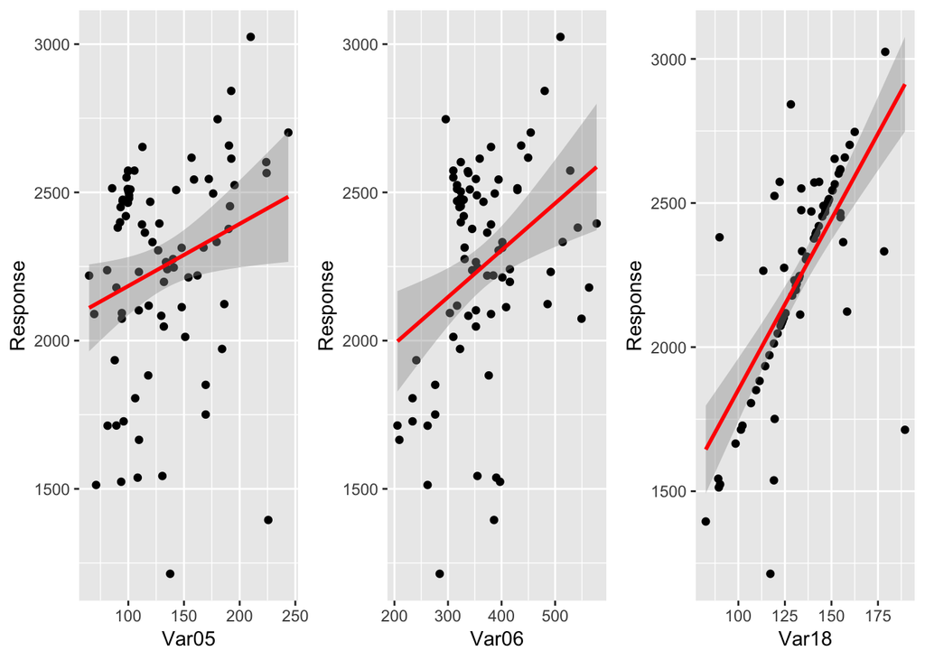

```r
library(ggplot2)
require(gridExtra)
p1 <- ggplot(xy1, aes(x=Var05, y=Response))+geom_point()+stat_smooth(method = "lm", col = "red")+labs(x="Var05",y="Response")
p2 <- ggplot(xy1, aes(x=Var06, y=Response))+geom_point()+stat_smooth(method = "lm", col = "red")+labs(x="Var06",y="Response")
p3 <- ggplot(xy1, aes(x=Var18, y=Response))+geom_point()+stat_smooth(method = "lm", col = "red")+labs(x="Var18",y="Response")
grid.arrange(p1, p2, p3, ncol=3)
```

Predictions-

```r
pred1 <- predict(reducedmodel4, test.data)
pred1 <- cbind(pred1, test.data$Response)
colnames(pred1) <- c("Prediction", "True")
View(pred1)
```

Comment: Errors-

```r
error <- mean((test.data$Response - predict.lm(reducedmodel4, test.data)) ^ 2)
actual.error <- sqrt(error)
actual.error
```

```
## [1] 171.0345
```

```r
error1 <- cbind(pred1, abs((test.data$Response - predict.lm(reducedmodel4, test.data))) / (0.01 * test.data$Response))
colnames(error1) <- c("Prediction", "True", "Error")
View(error1)
error1 <- as.data.frame(error1)
error.percentage <- mean(error1$Error)
error.percentage
```

```
## [1] 5.948719
```

Question 2-

Ctree Model-

Loading the required libraries-

```r
library(arules)
```

```r
library(arulesViz)
library(party)
```

Comment: Discretize the Response Variable

```r
xy1 <- read_excel("~/Desktop/Data Mining 809N/809N Project/xy1.xlsx")
xy1$Response <- as.numeric(xy1$Response)
xy1$Categorical_Response <- discretize(xy1$Response, breaks = 6)
levels(xy1$Categorical_Response)
```

```
## [1] "[1.21e+03,1.89e+03)" "[1.89e+03,2.19e+03)" "[2.19e+03,2.32e+03)"
## [4] "[2.32e+03,2.47e+03)" "[2.47e+03,2.55e+03)" "[2.55e+03,3.02e+03]"
```

```r
xy1$Categorical_Response <- discretize(xy1$Response, breaks = 6, labels = c("a", "b", "c", "d", "e", "f"))
levels(xy1$Categorical_Response)
```

```
## [1] "a" "b" "c" "d" "e" "f"
```

Comment: Refrences for each response class labels-

a = [1.21e+03,1.89e+03) b = [1.89e+03,2.19e+03) c = [2.19e+03,2.32e+03) d = [2.32e+03,2.47e+03) e = [2.47e+03,2.55e+03) f = [2.55e+03,3.02e+03]

```r
xy1$Categorical_Response <- as.factor(xy1$Categorical_Response)
View(xy1)
```

Comment: Spliting the dataset into testset and trainset

```r
set.seed(7658)
index <- sample(2, nrow(xy1), replace = T, prob = c(0.7, 0.3))
train.data <- xy1[index == 1, ]
View(train.data)
test.data <- xy1[index == 2, ]
View(test.data)
```

Comment: Confirming the split done

```r
dim(xy1)
```

```
## [1] 80 20
```

```r
dim(train.data)
```

```
## [1] 58 20
```

```r
dim(test.data)
```

```
## [1] 22 20
```

Comment: As we can see that the dataset has been splitted properly.

ctree Model-

```r
pQData_ctree <- ctree(Categorical_Response ~ Var05 + Var06 + Var18, data = train.data)
pQData_ctree
```

```
##
##   Conditional inference tree with 5 terminal nodes
##
## Response:  Categorical_Response
## Inputs:  Var05, Var06, Var18
## Number of observations:  58
##
## 1) Var18 <= 119.5; criterion = 0.997, statistic = 20.59
##   2)*  weights = 13
## 1) Var18 > 119.5
##   3) Var18 <= 128.9; criterion = 0.999, statistic = 24.427
##     4)*  weights = 7
##   3) Var18 > 128.9
##     5) Var18 <= 136.8; criterion = 0.999, statistic = 23.15
##       6)*  weights = 11
##     5) Var18 > 136.8
##       7) Var18 <= 150.6; criterion = 0.979, statistic = 14.042
##         8)*  weights = 15
##       7) Var18 > 150.6
##         9)*  weights = 12
```

Comment: If-then rules (found manually)-

1. If Var18 <= 119.5, then probability that categorical response belongs to [a, b, c, d, e, f] is [0.769, 0, 0.077, 0.077, 0.077, 0] respectively.
2. If Var18 > 119.5 and Var18 <= 128.9, then probability that categorical response belongs to [a, b, c, d, e, f] is [0, 0.714, 0.143, 0, 0, 0.143] respectively.
3. If Var18 > 128.9 and Var18 <= 136.8, then probability that categorical response belongs to [a, b, c, d, e, f] is [0, 0, 0.727, 0.091, 0.091, 0.091] respectively.
4. If Var18 > 136.8 and Var18 <= 150.6, then probability that categorical response belongs to [a, b, c, d, e, f] is [0, 0, 0, 0.2, 0.667, 0.133] respectively.
5. If Var18 > 150.6, then probability that categorical response belongs to [a, b, c, d, e, f] is [0.083, 0.083, 0, 0.25, 0, 0.583] respectively.

Plot-

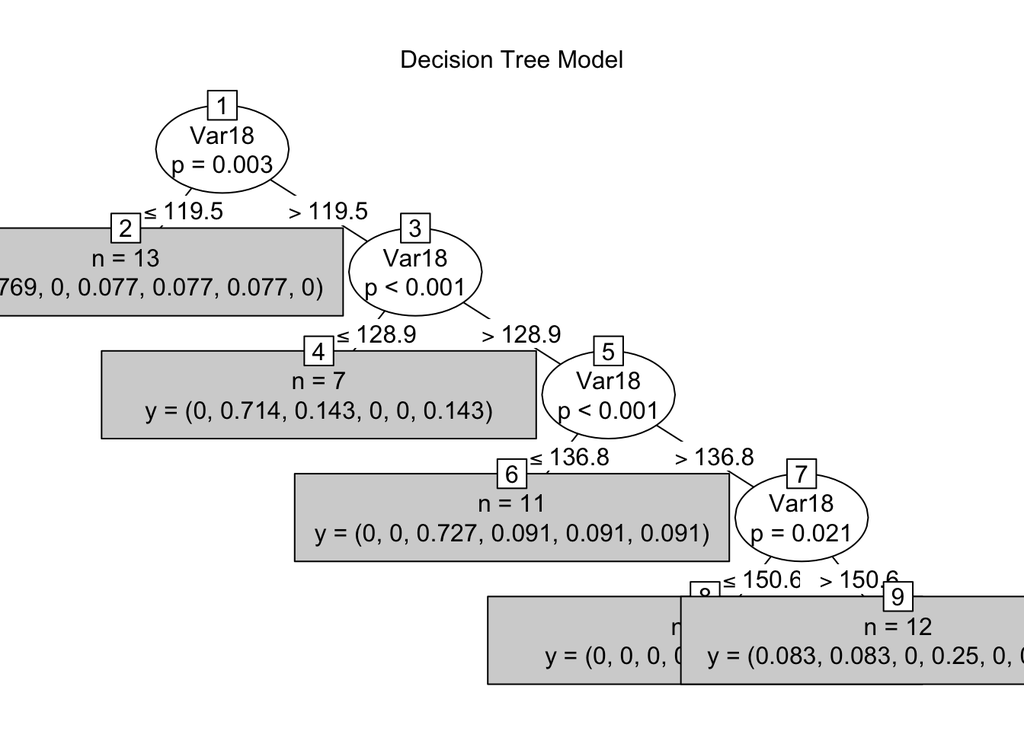

```r
plot(pQData_ctree, type = "simple", main = "Decision Tree Model")
```

Comment: Predictions from model-

```r
pred2 <- predict(pQData_ctree, test.data, type = "response")
pred2 <- data.frame(pred2, test.data$Categorical_Response)
colnames(pred2) <- c("Prediction", "True")
View(pred2)
```

Comment: Error-

```r
pred2 <- predict(pQData_ctree, test.data)
error_matrix <- table(Predicted = pred2, True = test.data$Categorical_Response)
error_matrix
```

```
##          True
## Predicted a b c d e f
##         a 3 3 0 0 0 0
##         b 0 3 0 0 0 1
##         c 0 1 2 0 0 0
##         d 0 0 0 0 0 0
##         e 0 0 1 4 1 0
##         f 0 0 0 1 0 2
```

```r
acc_val <- sum(diag(error_matrix)) / sum(error_matrix)
acc_val
```

```
## [1] 0.5
```

Comment: As we see, the accuracy in this case is around 50 % which is significantly less.

Decision tree using C5.0-

```r
library(arules)
library(arulesViz)
library(party)
xy1 <- read_excel("~/Desktop/Data Mining 809N/809N Project/xy1.xlsx")
xy1$Response <- as.numeric(xy1$Response)
xy1$Categorical_Response <- discretize(xy1$Response, breaks = 6)
levels(xy1$Categorical_Response)
```

```
## [1] "[1.21e+03,1.89e+03)" "[1.89e+03,2.19e+03)" "[2.19e+03,2.32e+03)"
## [4] "[2.32e+03,2.47e+03)" "[2.47e+03,2.55e+03)" "[2.55e+03,3.02e+03]"
```

```r
xy1$Categorical_Response <- discretize(xy1$Response, breaks = 6, labels = c("a", "b", "c", "d", "e", "f"))
levels(xy1$Categorical_Response)
```

```
## [1] "a" "b" "c" "d" "e" "f"
```

```r
xy1$Categorical_Response <- as.factor(xy1$Categorical_Response)
set.seed(7658)
index <- sample(2, nrow(xy1), replace = T, prob = c(0.7, 0.3))
train.data <- xy1[index == 1, ]
View(train.data)
test.data <- xy1[index == 2, ]
View(test.data)
library(C50)
tree <- C5.0(Categorical_Response ~ Var05 + Var06 + Var11 + Var15 + Var18, data = train.data)
tree
```

```
##
## Call:
## C5.0.formula(formula = Categorical_Response ~ Var05 + Var06 + Var11
##  + Var15 + Var18, data = train.data)
##
## Classification Tree
## Number of samples: 58
## Number of predictors: 5
##
## Tree size: 12
##
## Non-standard options: attempt to group attributes
```

Comment: If-then rules (found manually)-

1. If Var06 <= 284.5, then Categorical Response belongs to class a.
2. If Var06 > 284.5 and Var18 <= 136.8, Var18 <= 119.1 and Var15 <= 142 then Categorical Response belongs to class a.
3. If Var06 > 284.5 and Var18 <= 136.8, Var18 <= 119.1 and Var15 > 142 then Categorical Response belongs to class c.
4. If Var06 > 284.5 and Var18 <= 136.8, Var18 > 119.1 and Var15 <= 182 and Var06 <= 491.8 then Categorical Response belongs to class c.
5. If Var06 > 284.5 and Var18 <= 136.8, Var18 > 119.1 and Var15 <= 182 and Var06 > 491.8 then Categorical Response belongs to class b.
6. If Var06 > 284.5 and Var18 <= 136.8, Var18 > 119.1 and Var15 > 182 and Var18 <= 128.9 then Categorical Response belongs to class b.
7. If Var06 > 284.5 and Var18 <= 136.8, Var18 > 119.1 and Var15 > 182 and Var18 > 128.9 then Categorical Response belongs to class e.
8. If Var06 > 284.5 and Var18 > 136.8, Var18 <= 150.6, Var18 <= 146.6 and Var05 <= 109.6 then Categorical Response belongs to class e.
9. If Var06 > 284.5 and Var18 > 136.8, Var18 <= 150.6, Var18 <= 146.6 and Var05 > 109.6 then Categorical Response belongs to class d.
10. If Var06 > 284.5 and Var18 > 136.8, Var18 <= 150.6, Var18 > 146.6 then Categorical Response belongs to class e.
11. If Var06 > 284.5 and Var18 > 136.8, Var18 > 150.6 and Var05 <= 137.6 then Categorical Response belongs to class d.
12. If Var06 > 284.5 and Var18 > 136.8, Var18 > 150.6 and Var05 > 137.6 then Categorical Response belongs to class f.

Plot-

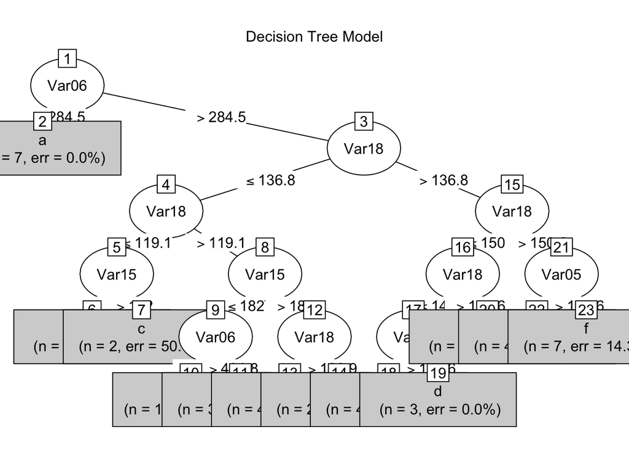

```r
plot(tree, type = "simple", main = "Decision Tree Model")
```

Comment: Predictions from model-

```r
pred3 <- predict(tree, test.data, type = "class")
pred3 <- data.frame(pred3, test.data$Categorical_Response)
colnames(pred3) <- c("Prediction", "True")
View(pred3)
```

Comment: Error-

```r
pred3 <- predict(tree, test.data)
error_matrix2 <- table(pred3, test.data$Categorical_Response)
error_matrix2
```

```
##
## pred3 a b c d e f
##     a 3 1 0 0 0 0
##     b 0 1 0 0 0 0
##     c 0 5 2 0 0 1
##     d 0 0 1 3 0 0
##     e 0 0 0 2 1 0
##     f 0 0 0 0 0 2
```

```r
acc_val2 <- sum(diag(error_matrix2)) / sum(error_matrix2)
acc_val2
```

```
## [1] 0.5454545
```

Comment: As we can see, the accuracy of the decision tree is increased from 0.5 to 0.5454 by using C5.0 algorithm.

If-then rules using apriori-

Creating a new data object with only required variables-

```r
xy1_rules <- xy1[, c(1, 6, 7, 12, 16, 19)]
View(xy1_rules)
```

Comment: Making each column a factor variable

```r
xy1_rules$Response <- discretize(xy1_rules$Response, breaks = 6, labels = c(1, 2, 3, 4, 5, 6))
```

Comment: In xy1_rules$Response, class [1, 2, 3, 4, 5, 6] corresponds to [[1.21e+03,1.89e+03), [1.89e+03,2.19e+03), [2.19e+03,2.32e+03), [2.32e+03,2.47e+03), [2.47e+03,2.55e+03), [2.55e+03,3.02e+03]] respectively.

```r
xy1_rules$Var05 <- discretize(xy1_rules$Var05, breaks = 3, labels = c(1, 2, 3))
```

Comment: In xy1_rules$Var05, class [1, 2, 3] corresponds to [[64.8,101), [101,146), [146,244]] respectively.

```r
xy1_rules$Var06 <- discretize(xy1_rules$Var06, breaks = 3, labels = c(1, 2, 3))
```

Comment: In xy1_rules$Var06, class [1, 2, 3] corresponds to [[206,326), [326,385), [385,578]] respectively.

```r
xy1_rules$Var11 <- discretize(xy1_rules$Var11, breaks = 3, labels = c(1, 2, 3))
```

Comment: In xy1_rules$Var11, class [1, 2, 3] corresponds to [[261,345), [345,420), [420,662]] respectively.

```r
xy1_rules$Var15 <- discretize(xy1_rules$Var15, breaks = 3, labels = c(1, 2, 3))
```

Comment: In xy1_rules$Var15, class [1, 2, 3] corresponds to [[112,139), [139,176), [176,200]] respectively.

```r
xy1_rules$Var18 <- discretize(xy1_rules$Var18, breaks = 3, labels = c(1, 2, 3))
```

Comment: In xy1_rules$Var18, class [1, 2, 3] corresponds to [82.5,125), [125,145), [145,190]] respectively.

```r
xy1_rules <- data.frame(xy1_rules)
```

Comment: Apply apriori function

```r
library(arules)
library(arulesViz)
rules <- apriori(xy1_rules)
```

```
## Apriori
##
## Parameter specification:
##  confidence minval smax arem  aval originalSupport maxtime support minlen
##         0.8    0.1    1 none FALSE            TRUE       5     0.1      1
##  maxlen target   ext
##      10  rules FALSE
##
## Algorithmic control:
##  filter tree heap memopt load sort verbose
##     0.1 TRUE TRUE  FALSE TRUE    2    TRUE
##
## Absolute minimum support count: 8
##
## set item appearances ...[0 item(s)] done [0.00s].
## set transactions ...[21 item(s), 80 transaction(s)] done [0.00s].
## sorting and recoding items ... [21 item(s)] done [0.00s].
## creating transaction tree ... done [0.00s].
## checking subsets of size 1 2 3 4 done [0.00s].
## writing ... [40 rule(s)] done [0.00s].
## creating S4 object  ... done [0.00s].
```

```r
rules.sorted <- sort(rules, by = "lift")
rules.pruned <- rules.sorted[!is.redundant(rules.sorted)]
inspect(rules.pruned)
```

```
##      lhs                          rhs          support confidence lift
## [1]  {Var15=1,Var18=1}         => {Response=1} 0.1500  0.9230769  5.274725
## [2]  {Var06=1,Var11=2,Var15=1} => {Response=1} 0.1000  0.8888889  5.079365
## [3]  {Var11=2,Var15=1}         => {Response=1} 0.1125  0.8181818  4.675325
## [4]  {Var06=1,Var15=1}         => {Response=1} 0.1125  0.8181818  4.675325
## [5]  {Response=1,Var11=2}      => {Var15=1}    0.1125  1.0000000  2.962963
## [6]  {Response=1,Var06=1}      => {Var15=1}    0.1125  1.0000000  2.962963
## [7]  {Var06=1,Var11=2,Var18=1} => {Var15=1}    0.1000  1.0000000  2.962963
## [8]  {Var06=3,Var11=1}         => {Var15=2}    0.1250  0.9090909  2.797203
## [9]  {Response=1}              => {Var15=1}    0.1625  0.9285714  2.751323
## [10] {Response=1}              => {Var18=1}    0.1625  0.9285714  2.751323
## [11] {Response=1,Var11=2}      => {Var06=1}    0.1000  0.8888889  2.633745
## [12] {Response=1,Var06=1}      => {Var11=2}    0.1000  0.8888889  2.633745
## [13] {Response=6,Var18=3}      => {Var05=3}    0.1000  0.8888889  2.633745
## [14] {Response=6,Var05=3}      => {Var18=3}    0.1000  0.8888889  2.633745
```

[output cut: 41 more lines]

Comment: There are 27 rules.